# ST2195 Coursework — Part 1: Random Walk Metropolis Algorithm

Your Name

2026-04-03

# 1 Introduction

This report implements and analyses the **Random Walk Metropolis** algorithm (a specific instance of the Metropolis–Hastings MCMC algorithm) applied to the **Laplace distribution**:

$$f(x) = \frac{1}{2}\,e^{-|x|}, \qquad x
\in \mathbb{R}$$

The Laplace distribution is symmetric around 0 with a sharp peak (heavier tails than the Normal). Its true mean is **0** and its true standard deviation is $\sqrt{2} \approx 1.4142$.

# 2 Part 1(a): Sampling from the Laplace Distribution

## 2.1 Algorithm Description

The **Random Walk Metropolis** algorithm generates a Markov chain $x_0, x_1, \ldots, x_N$ whose stationary distribution is $f(x)$.

**Step 1.** Choose initial value $x_0$, number of iterations $N$, and proposal standard deviation $s > 0$.

**Step 2.** For $i = 1, \ldots, N$:

1. Draw a **proposal** $x^* \sim \mathcal{N}(x_{i-1},\, s^2)$.
2. Compute the **log-acceptance ratio** (numerically safer than the raw ratio):
   $$\log r(x^*, x_{i-1}) =
   \log f(x^*) - \log f(x_{i-1}) = -|x^*| + |x_{i-1}|$$
3. Draw $u \sim \text{Uniform}(0,1)$.
4. If $\log u < \log r$, **accept**: set $x_i = x^*$.  
   Otherwise, **reject**: set $x_i = x_{i-1}$.

The full chain has $N + 1$ elements $(x_0, x_1, \ldots, x_N)$.

## 2.2 Implementation

```r
# -------------------------------------------------------------------
# Log of the target density  log f(x) = -log(2) - |x|
# We only need differences, so the constant -log(2) cancels.
# -------------------------------------------------------------------
log_target <- function(x) -abs(x)

# -------------------------------------------------------------------
# metropolis_rw()
#   N  : number of MCMC steps
#   s  : proposal standard deviation
#   x0 : starting value
#
# Returns a numeric vector of length N+1: (x_0, x_1, ..., x_N)
# -------------------------------------------------------------------
metropolis_rw <- function(N = 10000, s = 1, x0 = 0) {

  x <- numeric(N + 1)   # pre-allocate N+1 slots
  x[1] <- x0            # R is 1-indexed, so x[1] = x_0

  for (i in seq(2, N + 1)) {
    proposal <- rnorm(1, mean = x[i - 1], sd = s)

    # Log-acceptance ratio
    log_r <- log_target(proposal) - log_target(x[i - 1])

    # Accept or reject
    if (log(runif(1)) < log_r) {
      x[i] <- proposal
    } else {
      x[i] <- x[i - 1]
    }
  }

  return(x)   # length N+1
}
```

## 2.3 Running the Chain

We run the sampler with $N = 10000$, $s = 1$, $x_0 = 0$.

The returned vector has $N + 1 = \mathbf{10001}$ elements.  
We use $(x_1, \ldots, x_N)$ — **excluding** the initial seed $x_0$ — for all analysis below.

```r
chain   <- metropolis_rw(N = 10000, s = 1, x0 = 0)  # length 10 001
samples <- chain[-1]                                  # x_1 ... x_N  (10 000 values)

cat("Full chain length  (x_0 to x_N):", length(chain),   "[should be 10 001]\n")
```

```
## Full chain length  (x_0 to x_N): 10001 [should be 10 001]
```

```r
cat("Samples used       (x_1 to x_N):", length(samples), "[should be 10 000]\n")
```

```
## Samples used       (x_1 to x_N): 10000 [should be 10 000]
```

## 2.4 Visualisation: Histogram + KDE + True Laplace PDF

All three elements are overlaid in a **single figure** so the quality of the MCMC approximation can be judged at a glance.

| Layer | Colour | Role |
| --- | --- | --- |
| Histogram | light blue | Non-parametric density estimate from the samples |
| KDE | red | Smooth kernel density estimate |
| True PDF | black dashed | Theoretical Laplace(0,1) — the sampling target |

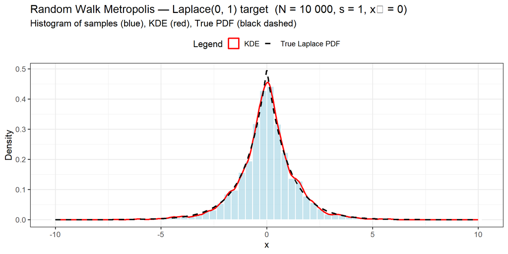

```r
library(ggplot2)

# True Laplace density on a fine grid
x_grid  <- seq(-10, 10, length.out = 800)
true_pdf <- 0.5 * exp(-abs(x_grid))
df_true  <- data.frame(x = x_grid, density = true_pdf)

# Data frame of MCMC samples
df_samples <- data.frame(x = samples)

ggplot(df_samples, aes(x = x)) +

  # 1. Histogram (density scale)
  geom_histogram(aes(y = after_stat(density)),
                 bins = 60, fill = "lightblue", colour = "white",
                 alpha = 0.7) +

  # 2. KDE
  geom_density(colour = "red", linewidth = 1, aes(linetype = "KDE")) +

  # 3. True Laplace PDF
  geom_line(data = df_true,
            aes(x = x, y = density, linetype = "True Laplace PDF"),
            colour = "black", linewidth = 1) +

  # Labels and theme
  scale_linetype_manual(name   = "Legend",
                        values = c("KDE" = "solid",
                                   "True Laplace PDF" = "dashed")) +
  labs(
    title    = "Random Walk Metropolis — Laplace(0, 1) target  (N = 10 000, s = 1, x\u2080 = 0)",
    subtitle = "Histogram of samples (blue), KDE (red), True PDF (black dashed)",
    x        = "x",
    y        = "Density"
  ) +
  theme_bw(base_size = 13) +
  theme(legend.position = "top")
```

## 2.5 Monte Carlo Estimates of Mean and Standard Deviation

The sample mean and sample standard deviation are **Monte Carlo estimates** of the true moments.

```r
sample_mean <- mean(samples)
sample_sd   <- sd(samples)

cat(sprintf("Sample mean               : %.6f\n",  sample_mean))
```

```
## Sample mean               : -0.000569
```

```r
cat(sprintf("Sample standard deviation : %.6f\n",  sample_sd))
```

```
## Sample standard deviation : 1.347895
```

```r
cat(sprintf("(True mean = 0,  true sd  = %.6f)\n", sqrt(2)))
```

```
## (True mean = 0,  true sd  = 1.414214)
```

The estimates are close to the true values, confirming that the sampler has successfully explored the Laplace distribution.

# 3 Part 1(b): Gelman–Rubin $\hat{R}$ Diagnostic

## 3.1 Background

A single MCMC chain is not enough to confirm convergence — it could be stuck in one region of the distribution. The **Gelman–Rubin** diagnostic compares **multiple chains** started from different initial values.

Given $J$ chains $\{x_i^{(j)}\}_{i=1}^{N}$, $j = 1, \ldots, J$:

**Within-chain statistics:**
$$M_j = \frac{1}{N}\sum_{i=1}^{N} x_i^{(j)}, \qquad
V_j = \frac{1}{N}\sum_{i=1}^{N}\bigl(x_i^{(j)} -
M_j\bigr)^2$$

**Between-chain statistics:**
$$W = \frac{1}{J}\sum_{j=1}^{J} V_j, \qquad
M = \frac{1}{J}\sum_{j=1}^{J} M_j, \qquad
B = \frac{1}{J}\sum_{j=1}^{J}(M_j - M)^2$$

**Diagnostic:**
$$\hat{R} =
\sqrt{\frac{B + W}{W}}$$

- $\hat{R} \approx 1$ → chains agree → **converged**
- $\hat{R} > 1.05$ → chains disagree → **not converged**

## 3.2 Implementation

```r
# -------------------------------------------------------------------
# compute_Rhat()
#   chains : a list of numeric vectors, each of length N+1
#            (the full chain including x_0)
# Returns the scalar R-hat value.
# -------------------------------------------------------------------
compute_Rhat <- function(chains) {

  J   <- length(chains)

  # Use x_1 ... x_N only (drop x_0 = first element)
  spc <- lapply(chains, function(ch) ch[-1])

  Mj <- sapply(spc, mean)              # within-chain means
  Vj <- sapply(spc, function(s)        # within-chain variances  (1/N, not 1/(N-1))
    mean((s - mean(s))^2))

  W    <- mean(Vj)                     # overall within-chain variance
  M    <- mean(Mj)                     # overall mean
  B    <- mean((Mj - M)^2)            # between-chain variance

  Rhat <- sqrt((B + W) / W)
  return(Rhat)
}

# -------------------------------------------------------------------
# run_chains()
#   Runs J chains from dispersed starting points and returns R-hat.
# -------------------------------------------------------------------
run_chains <- function(N = 2000, s = 0.001, J = 4) {
  starting_points <- c(-5, 0, 5, 10)
  chains <- lapply(seq_len(J),
                   function(j) metropolis_rw(N = N, s = s,
                                             x0 = starting_points[j]))
  compute_Rhat(chains)
}
```

## 3.3 $\hat{R}$ for N = 2000, s = 0.001, J = 4

With $s = 0.001$ the Gaussian proposal is extremely narrow — almost every proposal is accepted, but the chain barely moves from its starting value. Because the four chains begin at $-5, 0, 5, 10$ and cannot mix in only 2000 steps, we expect $\hat{R} \gg 1$.

```r
set.seed(0)
rhat_s001 <- run_chains(N = 2000, s = 0.001, J = 4)
cat(sprintf("R-hat (N=2000, s=0.001, J=4) = %.4f\n", rhat_s001))
```

```
## R-hat (N=2000, s=0.001, J=4) = 330.9400
```

The large value confirms that the algorithm has **not** converged at this choice of $s$.

## 3.4 $\hat{R}$ over a Grid of 1000 s Values

Keeping $N = 2000$ and $J = 4$ fixed, we evaluate $\hat{R}$ at **1000** equally spaced values of $s$ in $[0.001,\, 1]$.

## 3.5 Plot: $\hat{R}$ vs Proposal Standard Deviation $s$

```r
set.seed(1)
s_values    <- seq(0.001, 1, length.out = 1000)
Rhat_values <- sapply(s_values, function(s)
                 run_chains(N = 2000, s = s, J = 4))

cat(sprintf("Computed %d R-hat values.\n", length(Rhat_values)))
```

```
## Computed 1000 R-hat values.
```

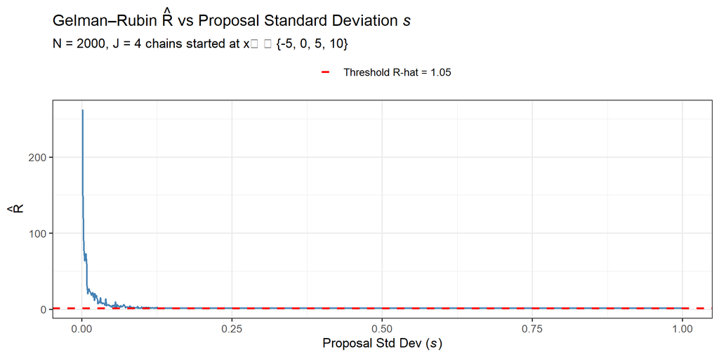

```r
df_rhat <- data.frame(s = s_values, Rhat = Rhat_values)

ggplot(df_rhat, aes(x = s, y = Rhat)) +
  geom_line(colour = "steelblue", linewidth = 0.8) +
  geom_hline(aes(yintercept = 1.05, linetype = "Threshold R-hat = 1.05"),
             colour = "red", linewidth = 1) +
  scale_linetype_manual(name = "", values = "dashed") +
  labs(
    title    = expression("Gelman\u2013Rubin " * hat(R) *
                          " vs Proposal Standard Deviation " * italic(s)),
    subtitle = "N = 2000, J = 4 chains started at x\u2080 \u2208 {-5, 0, 5, 10}",
    x        = expression("Proposal Std Dev (" * italic(s) * ")"),
    y        = expression(hat(R))
  ) +
  theme_bw(base_size = 13) +
  theme(legend.position = "top")
```

**Interpretation:**

- For **small $s$** (near 0.001) the chains are stuck near their starting values and $\hat{R}$ is very large — indicating poor convergence.
- As $s$ grows the chains mix more effectively and $\hat{R}$ drops toward the convergence threshold of 1.05, then continues to decline toward 1.